# Gapminder Report

Paula Andrea Martinez

August 8, 2018

## The gapminder dataset

```r
if (!file.exists("../data/SWCgapminder.csv")) {
  download.file(url = "http://tiny.cc/gapminder_data",
              destfile = "../data/SWCgapminder.csv")
}
```

```r
library(tidyverse)
```

```r
gapminder <- read_csv("../data/SWCgapminder.csv")
```

## Exploring the dataset

```r
glimpse(gapminder)
```

```
## Observations: 1,704
## Variables: 6
## $ country   <chr> "Afghanistan", "Afghanistan", "Afghanistan", "Afghan...
## $ year      <int> 1952, 1957, 1962, 1967, 1972, 1977, 1982, 1987, 1992...
## $ pop       <dbl> 8425333, 9240934, 10267083, 11537966, 13079460, 1488...
## $ continent <chr> "Asia", "Asia", "Asia", "Asia", "Asia", "Asia", "Asi...
## $ lifeExp   <dbl> 28.801, 30.332, 31.997, 34.020, 36.088, 38.438, 39.8...
## $ gdpPercap <dbl> 779.4453, 820.8530, 853.1007, 836.1971, 739.9811, 78...
```

## Question

My idea is to discover which countries have population growth increment about four times more than the original data (400%+), comparing the first data observed in 1952 and the last data observed in 2007.

## Analysis

The analysis is based on subset of the data, hence reducing it is a good idea to start with (select and filter). Then, a calculation between the two selected years is needed, for which making the data in wide format is useful. After that, producing the calculated increment percentange (could have been done in one column). Lastly, arranging the output to have the countries with major increment at the top. Filtering towards the end can be conveniently modified. The last two lines; mutate country as factor (serves to keep the arrangement for the subsequent plot), and removing increment_pop (only to make the table include the necessary display columns).

Note, continent was kept as it will be plotted as category, and aids in the conclusion. Lastly, for the plot, one can ignore the columns year 1952 and 2007. However it is beneficial to have it displayed in the column for visual comparison of population grow.

```r
countries_major_increment <-
gapminder %>%
    select(country, year, pop, continent) %>%
    filter(year == 1952 | year == 2007) %>%
    spread(key = year, value = pop) %>%
    mutate(increment_pop = `2007` - `1952`,
           increment_pop_percentage = round(increment_pop / `1952` * 100, 2)) %>%
    arrange(desc(increment_pop_percentage)) %>%
    filter(increment_pop_percentage >= 400) %>%
    mutate(country = factor(country, levels = country)) %>%
    select(-increment_pop)
```

## Results

The countries which have a population growth increment of about four times (400%+) more than the original data, comparing 1952 and 2007.

```r
countries_major_increment %>%
    knitr::kable(caption = "Table 1: Countries with 4 fold population increment between 1952 and 2007")
```

Table 1: Countries with 4 fold population increment between 1952 and 2007

| country | continent | 1952 | 2007 | increment_pop_percentage |
| --- | --- | --- | --- | --- |
| Kuwait | Asia | 160000 | 2505559 | 1465.97 |
| Jordan | Asia | 607914 | 6053193 | 895.73 |
| Djibouti | Africa | 63149 | 496374 | 686.04 |
| Saudi Arabia | Asia | 4005677 | 27601038 | 589.05 |
| Oman | Asia | 507833 | 3204897 | 531.09 |
| Cote d’Ivoire | Africa | 2977019 | 18013409 | 505.08 |
| Gambia | Africa | 284320 | 1688359 | 493.82 |
| Libya | Africa | 1019729 | 6036914 | 492.01 |
| Bahrain | Asia | 120447 | 708573 | 488.29 |
| Kenya | Africa | 6464046 | 35610177 | 450.90 |
| Syria | Asia | 3661549 | 19314747 | 427.50 |
| Iraq | Asia | 5441766 | 27499638 | 405.34 |
| Uganda | Africa | 5824797 | 29170398 | 400.80 |

Answering the question with a Lollipop plot inspired by https://www.r-graph-gallery.com/301-custom-lollipop-chart/

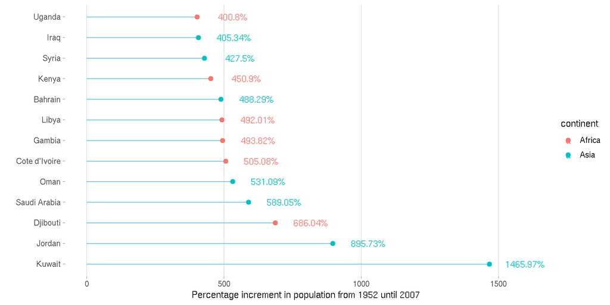

Figure 1: Countries with 4 fold population increment between 1952 and 2007

```r
  ggplot(countries_major_increment,
         aes(x = country, y = increment_pop_percentage, color = continent)) +
    geom_segment( aes(x = country, xend = country, y = 0, yend = increment_pop_percentage),
                   color = "skyblue") +
    geom_point( size = 2) +
    geom_text(aes(label = paste0(increment_pop_percentage, "%")), size = 4, nudge_y = 130) +
    theme_light() +
    coord_flip() +
    theme( panel.grid.major.y = element_blank(),
           panel.grid.minor  = element_blank(),
           panel.border = element_blank()
           ) +
    xlab("") +
    ylab("Percentage increment in population from 1952 until 2007")
```

## Conclusion

From the data analysed 13 countries had incremented their population by 4 times, comparing the observationa from 1952 and 2007. These 13 countries represent 7 Asian and 6 African countries.

The plot clearly displays Kuwait as the country with major population increment, also detailed in Table 1, from having 160000 people in 1952 and reaching to 2505559 in 5.5 decades (2007) is almost a 15 times population increment since 1952.

It is important to notice some facts putting in context our analysis. First of all, the information shown here is solely dependent on the data and its accuracy. After double checking external data, Kuwait seems to be receiving many expats which contributes to its population growth, so not only more births but external inflow of people. Another comparison to explore with the aid of external data is to see how the growth continued after 2007 [[1](https://en.wikipedia.org/wiki/List_of_countries_by_population_growth_rate)]. In respect to the external table, we can notice other facts, not only that population growth varied over the last ten years, in relation to the present analysis. Also, that some countries were not included in the original dataset, such as Qatar, South Sudan and United Arab Emirates. Hence our analysis is limited to our original observations.